# Homework 3

In this homework we study Local Interpretable Model-agnostic Explanations (LIME). LIME focuses on explaining the model's predictions for individual instances rather than providing global understanding of the model on the entirety of the dataset. The method learns an interpretable model locally around the prediction. LIME first transforms input (observation of interest $x$) to the model into interpreatble feature space ($x'$). Then LIME creates training dataset by uniformly sampling from $x'$ and creating perturbed samples $z'$. Lastly local model behaviour is explaained by approximating it by an interpretable surrogate model (e.g. linear regression).

To explore LIME we selected dataset and models from HW1, which are described below.

## Dataset

For our binary classification problem we selected QSAR-biodegradation dataset LINK, which has 17 features and 1055 rows. We changes classes labels from $\{1, 2\}$ to $\{0, 1\}$ for consistency with the procedure in HW1 (it was necessary to use BCELoss while training Neural Network Classifier). Class 0 has 699 instances and class 1 has $356$, thus this dataset's imbalance ratio is equal to $1.96$. The task is to discriminate ready (class $1$) and not ready (class $0$) biodegradable molecules based on molecular stucture descriptors.

### Selecting observations for LIME

We set random seed for reproductibility and split dataset into training and validation datasets 80:20. We perform feature scaling using `sklearn.preprocessing.StandardScaler`. Then we sampled 4 observations for valiation datasets, 2 from each class.

The selected observations are presented in the table below.

|  | V1 | V2 | V8 | V12 | V13 | V14 | V15 | V17 | V18 | V22 | V27 | V28 | V30 | V31 | V36 | V37 | V39 | TARGET |
| --- | --- | --- | --- | --- | --- | --- | --- | --- | --- | --- | --- | --- | --- | --- | --- | --- | --- | --- |
| 253 | -0.524653 | -0.0694426 | 1.41951 | 0.264144 | -0.775687 | -0.299239 | -0.672949 | -0.341806 | -0.89414 | 0.537324 | -0.35433 | 0.281606 | 0.10592 | -0.563974 | -0.337224 | 0.0109026 | -0.533223 | 1 |
| 279 | -0.524653 | -0.0124316 | 0.745908 | 0.264144 | -0.839017 | -0.299239 | -0.672949 | -0.489822 | -0.471182 | 0.151633 | -0.35433 | 0.281606 | -0.751856 | -0.563974 | -0.356053 | -0.657176 | -0.613844 | 1 |
| 1002 | 1.41747 | 1.87729 | -0.39487 | 0.264144 | 0.920539 | -0.26365 | 1.29818 | 0.630873 | 0.472339 | -0.244208 | 1.45952 | 0.00355073 | 5.032 | -0.599315 | 0.158288 | 1.10398 | 0.581106 | 0 |
| 626 | 1.32255 | -0.567552 | 1.20222 | 0.264144 | 0.968465 | -0.798759 | 0.92859 | 0.377131 | -1.28456 | 1.10571 | 0.90209 | 0.00355073 | 1.33472 | 0.0250407 | 0.798488 | 0.180598 | 0.98022 | 0 |

## Models

Since LIME is model-agnostic meaning that it does not depend on the model structure we can easily compare different models.

### Performance

Selected models performed as shown in the table below.

|  | recall | precision | f1 | accuracy | auc |
| --- | --- | --- | --- | --- | --- |
| GradientBoostingClassifier | 0.898305 | 0.688312 | 0.779412 | 0.85782 | 0.92568 |
| RandomForestClassifier | 0.830508 | 0.720588 | 0.771654 | 0.862559 | 0.931813 |
| LogisticRegression | 0.762712 | 0.714286 | 0.737705 | 0.848341 | 0.899309 |

## Results

### 1. Predictions for the selected observations

The predictions for the selected observations are presented below.

|  | 253 | 279 | 1002 | 626 |
| --- | --- | --- | --- | --- |
| TARGET | 1 | 1 | 0 | 0 |
| GradientBoostingClassifier | 1 | 1 | 0 | 0 |
| RandomForestClassifier | 1 | 0 | 0 | 0 |
| LogisticRegression | 1 | 1 | 0 | 0 |

Even though generally RandomForestClassifier had the best performance here it did not classify observation 279 correctly. All other predictions for all models were correct.

### 2. Calculate the decomposition of the selected predictions with LIME.

We calculate the decomposition for selected predictions from GradientBoostingClassifier. Predictions 1002 and 626 correspond to target class 0, while predictions 253 and 279 correspond to target class 1.

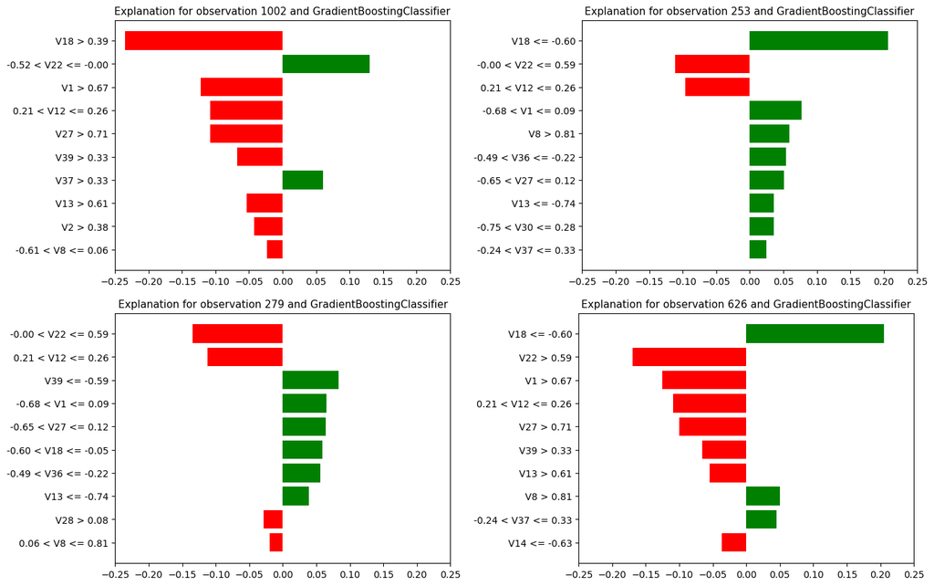

### 3. Compare LIME for various observations in the dataset. How stable are these explanations?

Since LIME algorithm involves randomness we are going to check few random seeds: 0, 1, 2, 3.

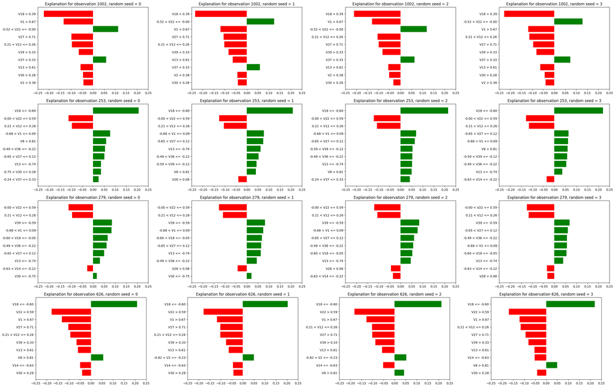

Generally we observe stable behaviour for 2-3 most important variables for each observation depending on the chosen seed.

For both observations from class 0 (626 and 1002) three most important variables are V18, V22 and V1. While for observation 626 their order is the same independent of random seed, in the case of observation 1002 V22 and V1 switch beetween second and third place in the importance ranking.

Observations from class 1 did not have similar decomposition. While for observation 253 two most important variables were V18 and V22 as for observations for class 0, for observation 279 V22, V12, V39 were to 3 most important variables across all random seeds.

### 4. Compare LIME between at least two different models. Are there any systematic differences across many observations?

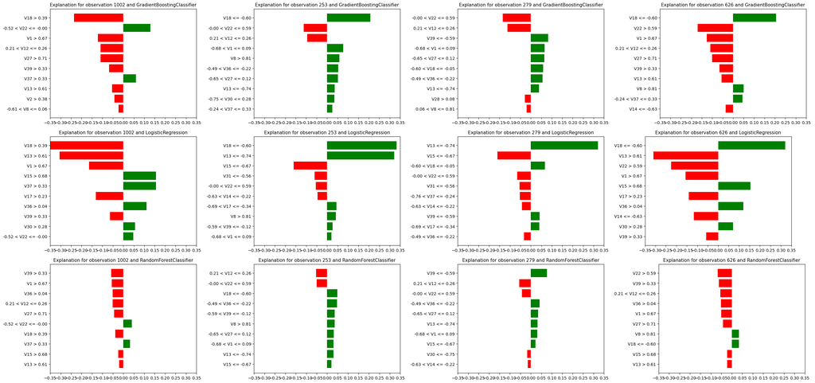

The main difference between the models is that the most important features for each observation have bigger contributions in explaining the prediction for LogisticRegression and GradientBoostingClassifier, than RandomForestClassifier, which might be the reason why it was the only model that predicted wrong class for observation 279. Also comparison between models confirms that observation 279 probably differs in an important way from other since it has rather different set of important variables for each model.

# Appendix

## Set up

```python
!pip install dalex
!pip install lime
```

```python
import dalex as dx
import xgboost
import lime

import sklearn
from sklearn.model_selection import train_test_split
from sklearn.compose import make_column_selector, make_column_transformer
from sklearn.pipeline import Pipeline
from sklearn.compose import ColumnTransformer

from sklearn.linear_model import LogisticRegression
from sklearn.ensemble import RandomForestClassifier, GradientBoostingClassifier, HistGradientBoostingClassifier

from sklearn.pipeline import make_pipeline
from sklearn.preprocessing import OneHotEncoder, OrdinalEncoder

import pandas as pd
import numpy as np
import random

from sklearn.datasets import fetch_openml

from sklearn.preprocessing import StandardScaler

from sklearn.model_selection import train_test_split
from sklearn.model_selection import cross_val_score
from sklearn.model_selection import StratifiedKFold

from sklearn import metrics
from sklearn.metrics import f1_score
from sklearn.metrics import roc_curve, auc
from sklearn.metrics import roc_auc_score
from sklearn.metrics import make_scorer
from sklearn.metrics import accuracy_score, classification_report, confusion_matrix

from sklearn.utils.class_weight import compute_sample_weight

import scipy.optimize as so
from scipy import diag, interp
from itertools import cycle

import numpy as np
import matplotlib.pyplot as plt
import pandas as pd
import seaborn as sns

import warnings
warnings.filterwarnings("ignore")
```

## Dataset

```python
url = "https://raw.githubusercontent.com/adrianstando/imbalanced-benchmarking-set/main/datasets/qsar-biodeg.csv"
df = pd.read_csv(url,index_col=0)
# change target labels 2->1 and 1->0
df["TARGET"]-= 1
display(df.head())
X = df.loc[:, df.columns != 'TARGET']
y = df["TARGET"]
```

|  | V1 | V2 | V8 | V12 | V13 | V14 | V15 | V17 | V18 | V22 | V27 | V28 | V30 | V31 | V36 | V37 | V39 | TARGET |
| --- | --- | --- | --- | --- | --- | --- | --- | --- | --- | --- | --- | --- | --- | --- | --- | --- | --- | --- |
| 0 | 3.919 | 2.6909 | 31.4 | 0.000 | 3.106 | 2.550 | 9.002 | 0.960 | 1.142 | 1.201 | 1.932 | 0.011 | 0.000 | 4.489 | 2.949 | 1.591 | 7.253 | 1 |
| 1 | 4.170 | 2.1144 | 30.8 | 0.000 | 2.461 | 1.393 | 8.723 | 0.989 | 1.144 | 1.104 | 2.214 | -0.204 | 0.000 | 1.542 | 3.315 | 1.967 | 7.257 | 1 |
| 2 | 3.932 | 3.2512 | 26.7 | 0.000 | 3.279 | 2.585 | 9.110 | 1.009 | 1.152 | 1.092 | 1.942 | -0.008 | 0.000 | 4.891 | 3.076 | 2.417 | 7.601 | 1 |
| 3 | 3.000 | 2.7098 | 20.0 | 0.000 | 2.100 | 0.918 | 6.594 | 1.108 | 1.167 | 1.024 | 1.414 | 1.073 | 8.361 | 1.333 | 3.046 | 5.000 | 6.690 | 1 |
| 4 | 4.236 | 3.3944 | 29.4 | -0.271 | 3.449 | 2.753 | 9.528 | 1.004 | 1.147 | 1.137 | 1.985 | -0.002 | 10.348 | 5.588 | 3.351 | 2.405 | 8.003 | 1 |

```python
# Spliting data
SEED = 0
X_train, X_test, y_train, y_test = train_test_split(X, y, test_size=0.2, random_state=SEED)
scaler = StandardScaler().fit(X_train)
#scaling - transforming
X_train = scaler.transform(X_train)
X_test = scaler.transform(X_test)
# convert back to dataframes
X_train = pd.DataFrame(X_train, columns = X.columns, index = y_train.index)
X_test = pd.DataFrame(X_test, columns = X.columns, index = y_test.index)
```

### Selecting observations for LIME

```python
np.random.seed(SEED)
y_test_0 = y_test[y_test == 0]
y_test_1 = y_test[y_test == 1]

idx_0 = np.random.choice(y_test_0.index, 2)
idx_1 = np.random.choice(y_test_1.index, 2)
idx = np.concatenate((idx_1, idx_0))

obs_var = X_test.loc[idx]
obs_target = y_test[idx].to_frame()
obs_df = obs_var.join(obs_target)
display(obs_df)
```

|  | V1 | V2 | V8 | V12 | V13 | V14 | V15 | V17 | V18 | V22 | V27 | V28 | V30 | V31 | V36 | V37 | V39 | TARGET |
| --- | --- | --- | --- | --- | --- | --- | --- | --- | --- | --- | --- | --- | --- | --- | --- | --- | --- | --- |
| 253 | -0.524653 | -0.069443 | 1.419510 | 0.264144 | -0.775687 | -0.299239 | -0.672949 | -0.341806 | -0.894140 | 0.537324 | -0.354330 | 0.281606 | 0.105920 | -0.563974 | -0.337224 | 0.010903 | -0.533223 | 1 |
| 279 | -0.524653 | -0.012432 | 0.745908 | 0.264144 | -0.839017 | -0.299239 | -0.672949 | -0.489822 | -0.471182 | 0.151633 | -0.354330 | 0.281606 | -0.751856 | -0.563974 | -0.356053 | -0.657176 | -0.613844 | 1 |
| 1002 | 1.417468 | 1.877287 | -0.394870 | 0.264144 | 0.920539 | -0.263650 | 1.298176 | 0.630873 | 0.472339 | -0.244208 | 1.459517 | 0.003551 | 5.032002 | -0.599315 | 0.158288 | 1.103983 | 0.581106 | 0 |
| 626 | 1.322553 | -0.567552 | 1.202219 | 0.264144 | 0.968465 | -0.798759 | 0.928590 | 0.377131 | -1.284563 | 1.105711 | 0.902090 | 0.003551 | 1.334718 | 0.025041 | 0.798488 | 0.180598 | 0.980220 | 0 |

```python
print(obs_df.to_markdown(index=True))
```

```
|      |        V1 |         V2 |        V8 |      V12 |       V13 |       V14 |       V15 |       V17 |       V18 |       V22 |      V27 |        V28 |       V30 |        V31 |       V36 |        V37 |       V39 |   TARGET |
|-----:|----------:|-----------:|----------:|---------:|----------:|----------:|----------:|----------:|----------:|----------:|---------:|-----------:|----------:|-----------:|----------:|-----------:|----------:|---------:|
|  253 | -0.524653 | -0.0694426 |  1.41951  | 0.264144 | -0.775687 | -0.299239 | -0.672949 | -0.341806 | -0.89414  |  0.537324 | -0.35433 | 0.281606   |  0.10592  | -0.563974  | -0.337224 |  0.0109026 | -0.533223 |        1 |
|  279 | -0.524653 | -0.0124316 |  0.745908 | 0.264144 | -0.839017 | -0.299239 | -0.672949 | -0.489822 | -0.471182 |  0.151633 | -0.35433 | 0.281606   | -0.751856 | -0.563974  | -0.356053 | -0.657176  | -0.613844 |        1 |
| 1002 |  1.41747  |  1.87729   | -0.39487  | 0.264144 |  0.920539 | -0.26365  |  1.29818  |  0.630873 |  0.472339 | -0.244208 |  1.45952 | 0.00355073 |  5.032    | -0.599315  |  0.158288 |  1.10398   |  0.581106 |        0 |
|  626 |  1.32255  | -0.567552  |  1.20222  | 0.264144 |  0.968465 | -0.798759 |  0.92859  |  0.377131 | -1.28456  |  1.10571  |  0.90209 | 0.00355073 |  1.33472  |  0.0250407 |  0.798488 |  0.180598  |  0.98022  |        0 |
```

## Models

```python
models = {
    'GradientBoostingClassifier': GradientBoostingClassifier(random_state=SEED, n_estimators=100),
    'RandomForestClassifier': RandomForestClassifier(random_state=SEED, n_estimators=300, max_depth=None),
    'LogisticRegression': LogisticRegression(random_state=SEED, penalty='l2', solver = 'lbfgs'),
    }

explainers = {}
for name, model in models.items():
    model.fit(X_train, y_train)
    explainer = dx.Explainer(model, X_test, y_test)
    # save explainer
    explainers[name] = explainer
```

[output not shown]

```python
performance = pd.concat([explainer.model_performance().result for explainer in explainers.values()], axis=0)
performance
```

|  | recall | precision | f1 | accuracy | auc |
| --- | --- | --- | --- | --- | --- |
| GradientBoostingClassifier | 0.898305 | 0.688312 | 0.779412 | 0.857820 | 0.925680 |
| RandomForestClassifier | 0.830508 | 0.720588 | 0.771654 | 0.862559 | 0.931813 |
| LogisticRegression | 0.762712 | 0.714286 | 0.737705 | 0.848341 | 0.899309 |

```python
print(performance.to_markdown(index=True))
```

```
|                            |   recall |   precision |       f1 |   accuracy |      auc |
|:---------------------------|---------:|------------:|---------:|-----------:|---------:|
| GradientBoostingClassifier | 0.898305 |    0.688312 | 0.779412 |   0.85782  | 0.92568  |
| RandomForestClassifier     | 0.830508 |    0.720588 | 0.771654 |   0.862559 | 0.931813 |
| LogisticRegression         | 0.762712 |    0.714286 | 0.737705 |   0.848341 | 0.899309 |
```

## Results

### 1. Predictions for the selected observations

```python
pred_df = obs_target.copy()
for name, model in models.items():
    pred_df[name] = model.predict(obs_var)
display(pred_df.T)
```

|  | 253 | 279 | 1002 | 626 |
| --- | --- | --- | --- | --- |
| TARGET | 1 | 1 | 0 | 0 |
| GradientBoostingClassifier | 1 | 1 | 0 | 0 |
| RandomForestClassifier | 1 | 0 | 0 | 0 |
| LogisticRegression | 1 | 1 | 0 | 0 |

```python
print(pred_df.T.to_markdown(index=True))
```

```
|                            |   253 |   279 |   1002 |   626 |
|:---------------------------|------:|------:|-------:|------:|
| TARGET                     |     1 |     1 |      0 |     0 |
| GradientBoostingClassifier |     1 |     1 |      0 |     0 |
| RandomForestClassifier     |     1 |     0 |      0 |     0 |
| LogisticRegression         |     1 |     1 |      0 |     0 |
```

### 2. Calculate the decomposition of the selected predictions with LIME.

We calculate the decomposition for selected predictions from GradientBoostingClassifier.

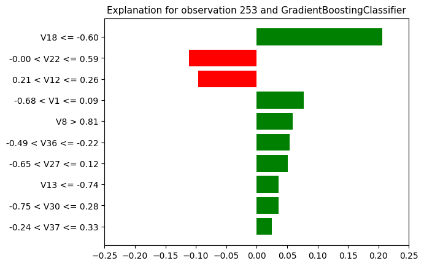

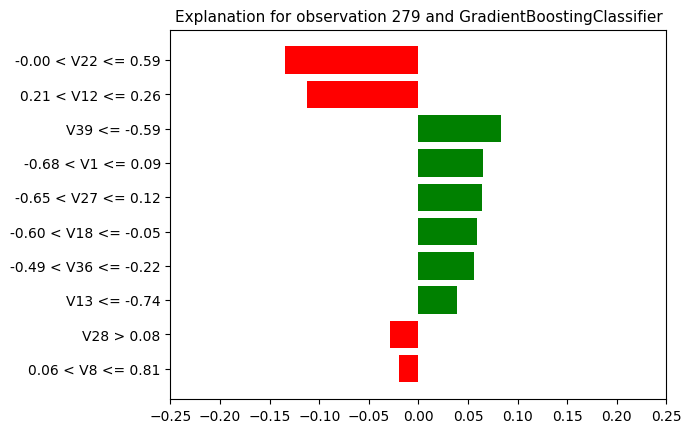

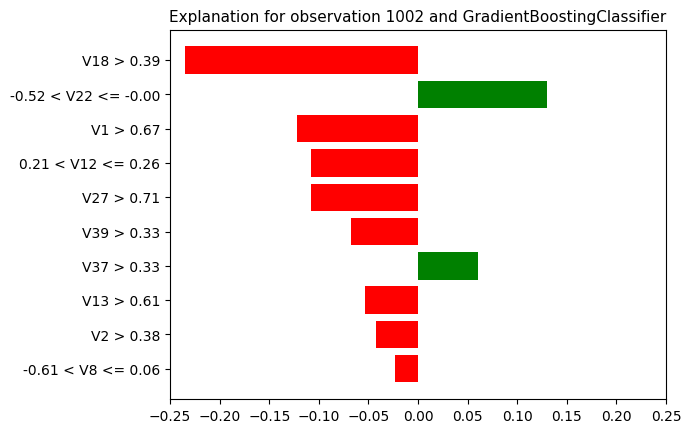

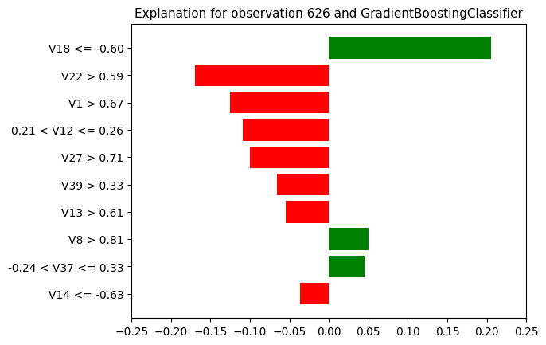

```python
random.seed(SEED)
np.random.seed(SEED)
name = 'GradientBoostingClassifier'
explainer = explainers[name]

output_dir = 'figures/compare_observations'
if not os.path.exists(output_dir):
    os.makedirs(output_dir)

for index in obs_var.index:
  observation = obs_var.loc[index]
  exp = explainer.predict_surrogate(observation)
  exp.plot(return_figure=True)
  plt.xlim(-0.25, 0.25)
  plt.xticks(np.arange(-0.25, 0.25+0.05, 0.05))
  plt.title(f'Explanation for observation {index} and {name}', fontsize=11)
  plt.savefig(f'{output_dir}/{name}_observation_{index}.png', bbox_inches='tight')
```

### 3. Compare LIME for various observations in the dataset. How stable are these explanations?

Since LIME algorithm involves randomness we are going to check few random seeds for selected observations and their predictions with GradientBoostingClassifier.

```python
import os
```

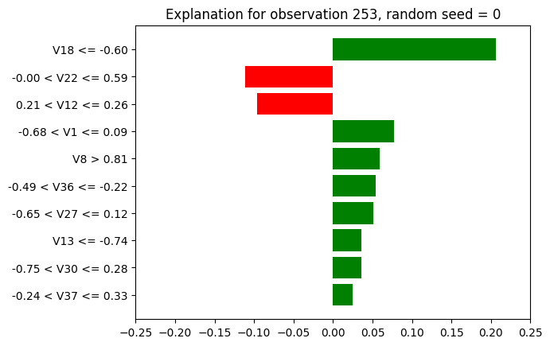

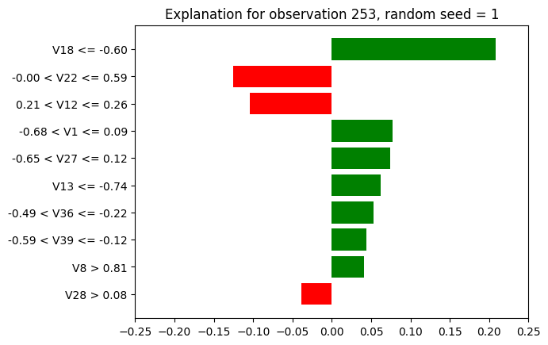

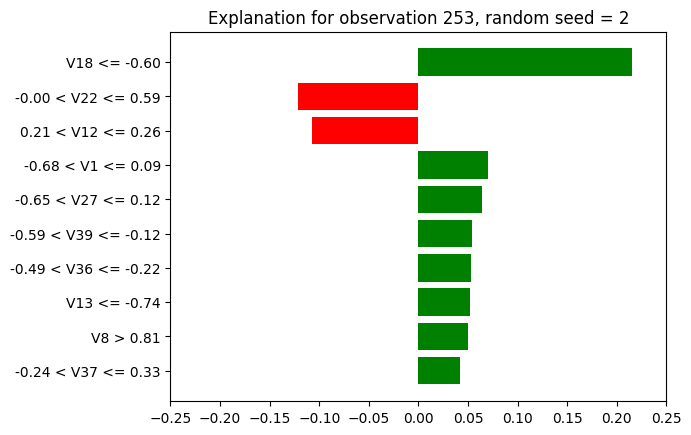

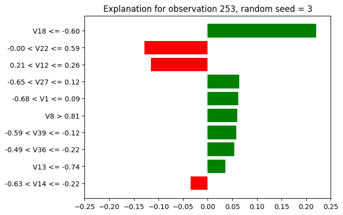

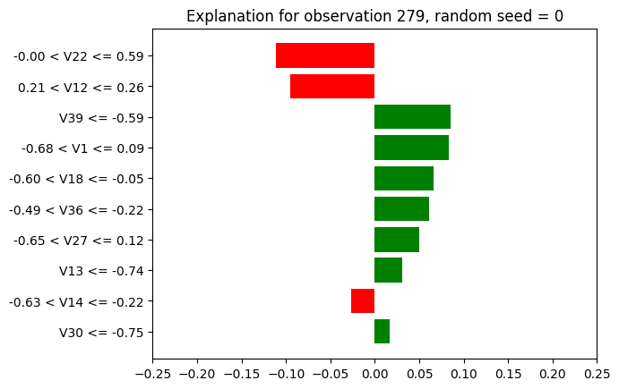

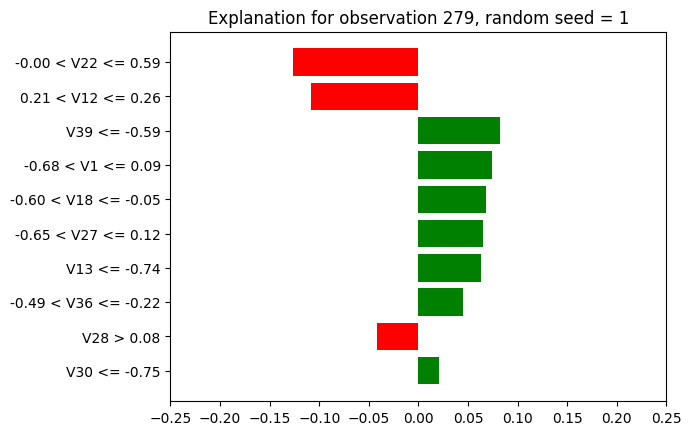

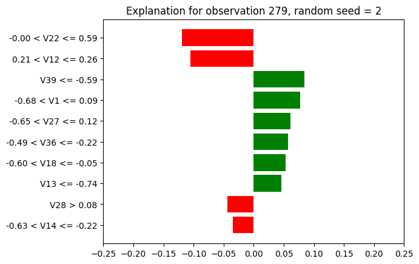

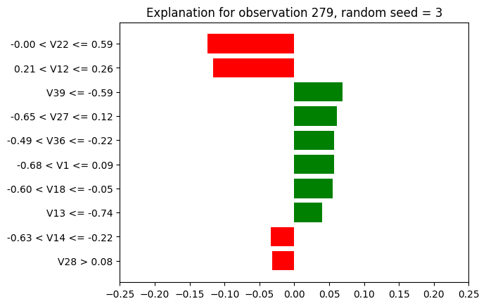

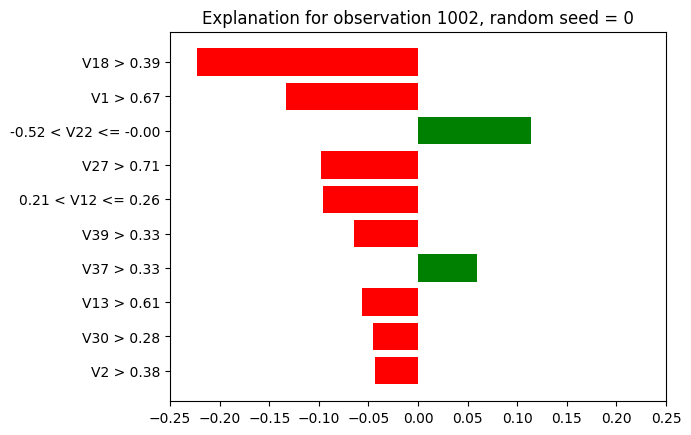

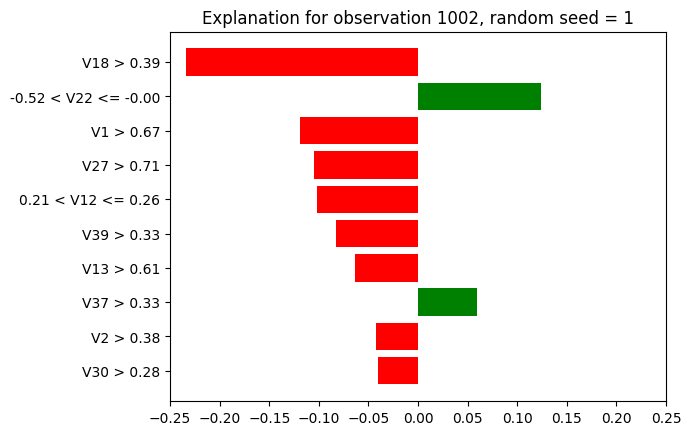

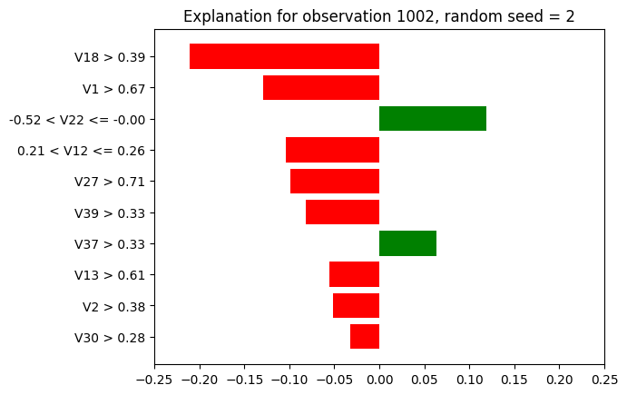

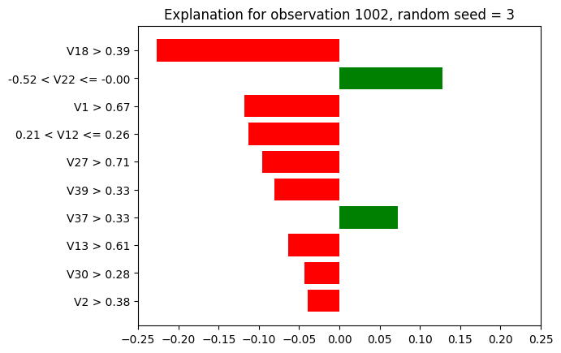

[4 more figures not shown]

```python
name = 'GradientBoostingClassifier'
explainer = explainers[name]

output_dir = 'figures/compare_random_seed'
if not os.path.exists(output_dir):
    os.makedirs(output_dir)

for index in obs_var.index:
  observation = obs_var.loc[index]
  for seed in range(4):
      random.seed(seed)
      np.random.seed(seed)
      exp = explainer.predict_surrogate(observation)
      exp.plot(return_figure=True)
      plt.xlim(-0.25, 0.25)
      plt.xticks(np.arange(-0.25, 0.25+0.05, 0.05))
      plt.title(f'Explanation for observation {index}, random seed = {seed}')
      plt.savefig(f'{output_dir}/{name}_observation_{index}_seed_{seed}.png', bbox_inches='tight')
```

### 4. Compare LIME between at least two different models. Are there any systematic differences across many observations?

Now we compare explanations for three different models the same seed=0 and all 4 selected observations.

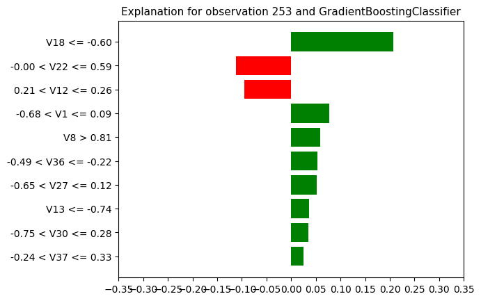

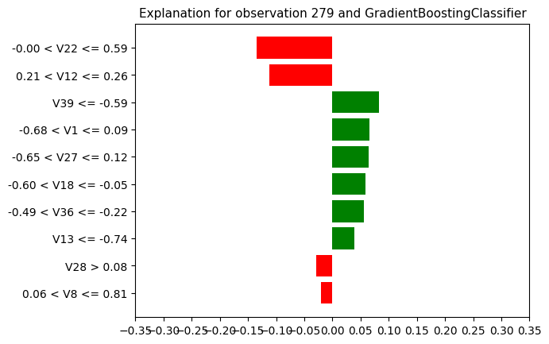

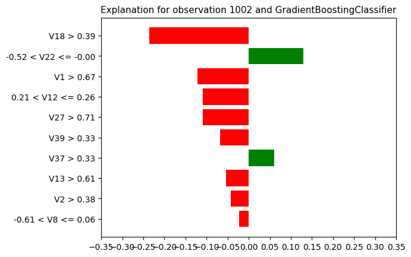

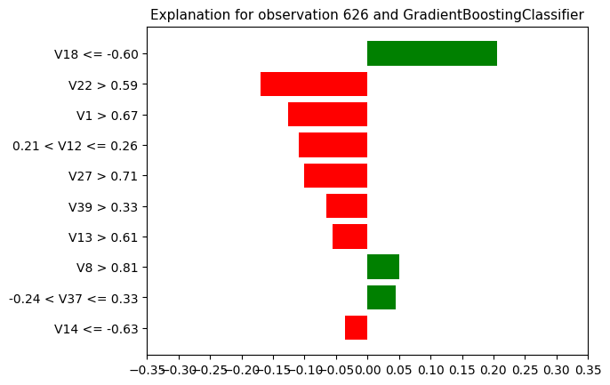

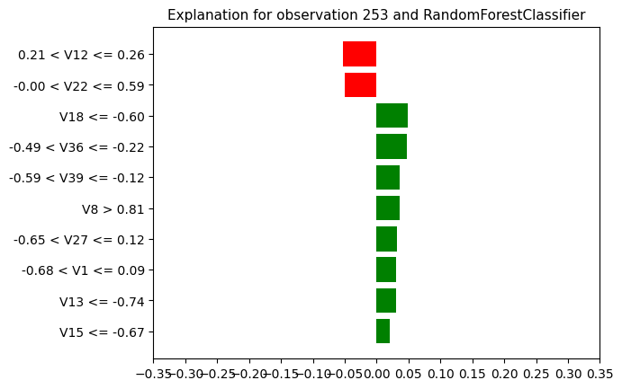

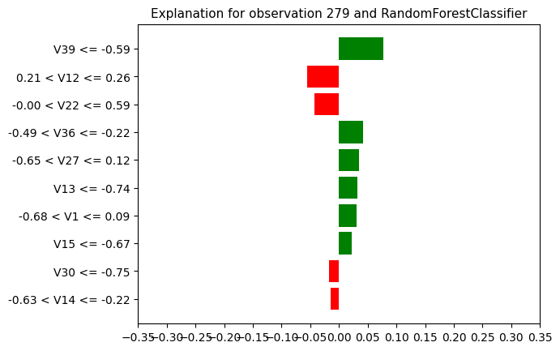

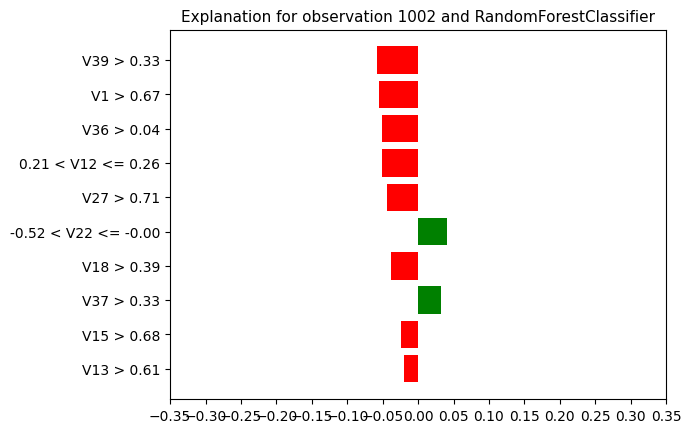

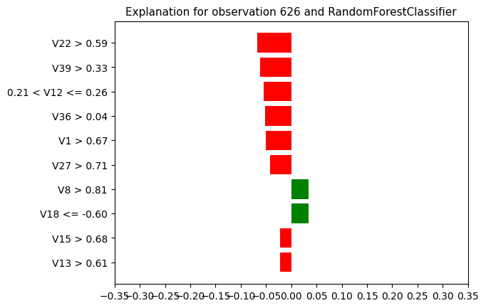

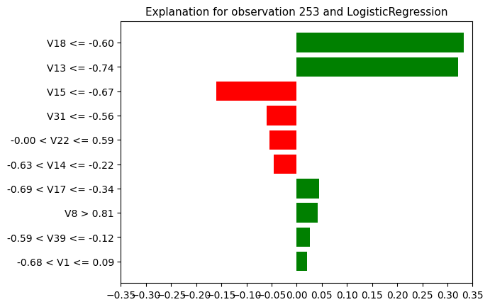

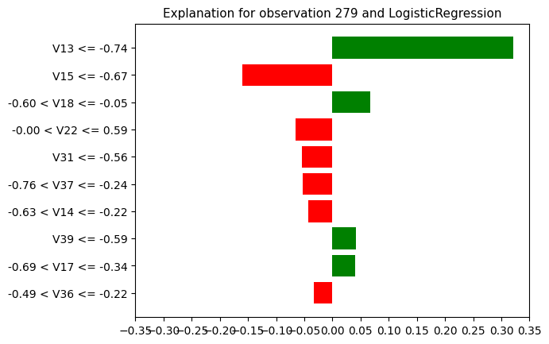

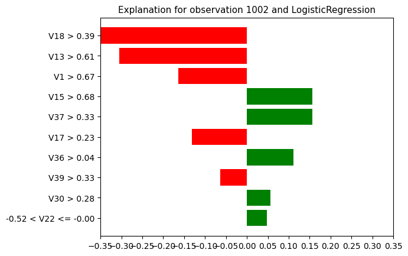

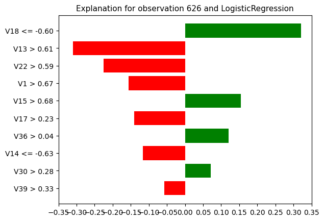

```python
random.seed(SEED)
np.random.seed(SEED)

output_dir = 'figures/compare_models'
if not os.path.exists(output_dir):
    os.makedirs(output_dir)

for name in explainers:
  explainer = explainers[name]
  for index in obs_var.index:
    observation = obs_var.loc[index]
    exp = explainer.predict_surrogate(observation)
    exp.plot(return_figure=True)
    plt.xlim(-0.35, 0.35)
    plt.xticks(np.arange(-0.35, 0.35+0.05, 0.05))
    plt.title(f'Explanation for observation {index} and {name}', fontsize=11)
    plt.savefig(f'{output_dir}/{name}_observation_{index}.png', bbox_inches='tight')
```